## EasyVisa Project

*Marks: 60*

## Problem Statement

# EasyVisa Project

## Context:

Business communities in the United States are facing high demand for human resources, but one of the constant challenges is identifying and attracting the right talent, which is perhaps the most important element in remaining competitive. Companies in the United States look for hard-working, talented, and qualified individuals both locally as well as abroad.

The Immigration and Nationality Act (INA) of the US permits foreign workers to come to the United States to work on either a temporary or permanent basis. The act also protects US workers against adverse impacts on their wages or working conditions by ensuring US employers' compliance with statutory requirements when they hire foreign workers to fill workforce shortages. The immigration programs are administered by the Office of Foreign Labor Certification (OFLC).

OFLC processes job certification applications for employers seeking to bring foreign workers into the United States and grants certifications in those cases where employers can demonstrate that there are not sufficient US workers available to perform the work at wages that meet or exceed the wage paid for the occupation in the area of intended employment.

## Objective:

In FY 2016, the OFLC processed 775,979 employer applications for 1,699,957 positions for temporary and permanent labor certifications. This was a nine percent increase in the overall number of processed applications from the previous year. The process of reviewing every case is becoming a tedious task as the number of applicants is increasing every year.

The increasing number of applicants every year calls for a Machine Learning based solution that can help in shortlisting the candidates having higher chances of VISA approval. OFLC has hired your firm EasyVisa for data-driven solutions. You as a data scientist have to analyze the data provided and, with the help of a classification model:

- Facilitate the process of visa approvals.
- Recommend a suitable profile for the applicants for whom the visa should be certified or denied based on the drivers that significantly influence the case status.

## Data Description

The data contains the different attributes of the employee and the employer. The detailed data dictionary is given below.

- case_id: ID of each visa application
- continent: Information of continent the employee
- education_of_employee: Information of education of the employee
- has_job_experience: Does the employee has any job experience? Y= Yes; N = No
- requires_job_training: Does the employee require any job training? Y = Yes; N = No
- no_of_employees: Number of employees in the employer's company
- yr_of_estab: Year in which the employer's company was established
- region_of_employment: Information of foreign worker's intended region of employment in the US.
- prevailing_wage: Average wage paid to similarly employed workers in a specific occupation in the area of intended employment. The purpose of the prevailing wage is to ensure that the foreign worker is not underpaid compared to other workers offering the same or similar service in the same area of employment.
- unit_of_wage: Unit of prevailing wage. Values include Hourly, Weekly, Monthly, and Yearly.
- full_time_position: Is the position of work full-time? Y = Full Time Position; N = Part Time Position
- case_status: Flag indicating if the Visa was certified or denied

```python
#!pip install xgboost
```

## Importing necessary libraries and data

```python
# Libraries to help with reading and manipulating data
import numpy as np
import pandas as pd

# Library to split data
from sklearn.model_selection import train_test_split

# Libaries to help with data visualization
import matplotlib.pyplot as plt
%matplotlib inline
import seaborn as sns

# Libraries of different ensemble classifiers
from sklearn.ensemble import (
    BaggingClassifier,
    RandomForestClassifier,
    AdaBoostClassifier,
    GradientBoostingClassifier,
    StackingClassifier,
)

from xgboost import XGBClassifier
from sklearn.tree import DecisionTreeClassifier

# Libraries to get metric scores
from sklearn import metrics
from sklearn.metrics import (
    confusion_matrix,
    accuracy_score,
    precision_score,
    recall_score,
    f1_score,
)

# Library to tune models
from sklearn.model_selection import GridSearchCV

# Remove the limit for displayed columns
pd.set_option('display.max_columns', None)

# Set the limit for displayed rows
pd.set_option('display.max_rows', 100)

import warnings
warnings.filterwarnings('ignore')
```

```python
# load the data set
visa = pd.read_csv('/Users/kimberly/Desktop/EasyVisa.csv')
```

```python
# Create copy of data set
data = visa.copy()
```

## Data Overview

- Observations
- Sanity checks

```python
# Return the first 5 rows
data.head()
```

|  | case_id | continent | education_of_employee | has_job_experience | requires_job_training | no_of_employees | yr_of_estab | region_of_employment | prevailing_wage | unit_of_wage | full_time_position | case_status |
| --- | --- | --- | --- | --- | --- | --- | --- | --- | --- | --- | --- | --- |
| 0 | EZYV01 | Asia | High School | N | N | 14513 | 2007 | West | 592.2029 | Hour | Y | Denied |
| 1 | EZYV02 | Asia | Master's | Y | N | 2412 | 2002 | Northeast | 83425.6500 | Year | Y | Certified |
| 2 | EZYV03 | Asia | Bachelor's | N | Y | 44444 | 2008 | West | 122996.8600 | Year | Y | Denied |
| 3 | EZYV04 | Asia | Bachelor's | N | N | 98 | 1897 | West | 83434.0300 | Year | Y | Denied |
| 4 | EZYV05 | Africa | Master's | Y | N | 1082 | 2005 | South | 149907.3900 | Year | Y | Certified |

```python
# Return the last 5 rows
data.tail()
```

|  | case_id | continent | education_of_employee | has_job_experience | requires_job_training | no_of_employees | yr_of_estab | region_of_employment | prevailing_wage | unit_of_wage | full_time_position | case_status |
| --- | --- | --- | --- | --- | --- | --- | --- | --- | --- | --- | --- | --- |
| 25475 | EZYV25476 | Asia | Bachelor's | Y | Y | 2601 | 2008 | South | 77092.57 | Year | Y | Certified |
| 25476 | EZYV25477 | Asia | High School | Y | N | 3274 | 2006 | Northeast | 279174.79 | Year | Y | Certified |
| 25477 | EZYV25478 | Asia | Master's | Y | N | 1121 | 1910 | South | 146298.85 | Year | N | Certified |
| 25478 | EZYV25479 | Asia | Master's | Y | Y | 1918 | 1887 | West | 86154.77 | Year | Y | Certified |
| 25479 | EZYV25480 | Asia | Bachelor's | Y | N | 3195 | 1960 | Midwest | 70876.91 | Year | Y | Certified |

```python
# Return the number of rows and columns
data.shape
```

```
(25480, 12)
```

#### Observations

- The data set has 25,480 rows and 12 columns.

```python
# Return a summary of the data
data.info()
```

```
<class 'pandas.core.frame.DataFrame'>
RangeIndex: 25480 entries, 0 to 25479
Data columns (total 12 columns):
 #   Column                 Non-Null Count  Dtype
---  ------                 --------------  -----
 0   case_id                25480 non-null  object
 1   continent              25480 non-null  object
 2   education_of_employee  25480 non-null  object
 3   has_job_experience     25480 non-null  object
 4   requires_job_training  25480 non-null  object
 5   no_of_employees        25480 non-null  int64
 6   yr_of_estab            25480 non-null  int64
 7   region_of_employment   25480 non-null  object
 8   prevailing_wage        25480 non-null  float64
 9   unit_of_wage           25480 non-null  object
 10  full_time_position     25480 non-null  object
 11  case_status            25480 non-null  object
dtypes: float64(1), int64(2), object(9)
memory usage: 2.3+ MB
```

#### Observations

- There are 9 columns of data type object (string), 2 columns of data type integer, and 1 column of data type float.
- case_id will be unnecessary in the analysis of the model, so we will remove it to improve efficiency.

```python
# Remove column case_id
data.drop(columns='case_id', inplace=True)
```

```python
# Re-check the summary to see that case_id has been dropped
data.info()
```

```
<class 'pandas.core.frame.DataFrame'>
RangeIndex: 25480 entries, 0 to 25479
Data columns (total 11 columns):
 #   Column                 Non-Null Count  Dtype
---  ------                 --------------  -----
 0   continent              25480 non-null  object
 1   education_of_employee  25480 non-null  object
 2   has_job_experience     25480 non-null  object
 3   requires_job_training  25480 non-null  object
 4   no_of_employees        25480 non-null  int64
 5   yr_of_estab            25480 non-null  int64
 6   region_of_employment   25480 non-null  object
 7   prevailing_wage        25480 non-null  float64
 8   unit_of_wage           25480 non-null  object
 9   full_time_position     25480 non-null  object
 10  case_status            25480 non-null  object
dtypes: float64(1), int64(2), object(8)
memory usage: 2.1+ MB
```

```python
# Check for duplicate values
data.duplicated().sum()
```

```
0
```

#### Observations

- There are no duplicate values in the data set.

## Exploratory Data Analysis (EDA)

- EDA is an important part of any project involving data.
- It is important to investigate and understand the data better before building a model with it.
- A few questions have been mentioned below which will help you approach the analysis in the right manner and generate insights from the data.
- A thorough analysis of the data, in addition to the questions mentioned below, should be done.

**Leading Questions**:

1. Those with higher education may want to travel abroad for a well-paid job. Does education play a role in Visa certification?
2. Do different regions have different education requirements?
3. Does region affect certification status?
4. How does the visa status vary across different continents?
5. Does work experience impact certification status?
6. Do employees with work experience require job training?
7. How does the visa status change with the prevailing wage?
8. How does prevailing wage vary across regions?
9. Do wage units impact certification status?

```python
# Describe numerical stats
data.describe().T
```

|  | count | mean | std | min | 25% | 50% | 75% | max |
| --- | --- | --- | --- | --- | --- | --- | --- | --- |
| no_of_employees | 25480.0 | 5667.043210 | 22877.928848 | -26.0000 | 1022.00 | 2109.00 | 3504.0000 | 602069.00 |
| yr_of_estab | 25480.0 | 1979.409929 | 42.366929 | 1800.0000 | 1976.00 | 1997.00 | 2005.0000 | 2016.00 |
| prevailing_wage | 25480.0 | 74455.814592 | 52815.942327 | 2.1367 | 34015.48 | 70308.21 | 107735.5125 | 319210.27 |

#### Observations

- The average number of employees is 5,667, and the median is 2,109.
- The minimum number is -26. This is not a valid data entry. We will address this.
- The earliest year of establishment is 1800 while the newest is 2016.
- The average prevailing wage is $74,456.
- The minimum prevailing wage is $2.14.

```python
# Check for negative values in no_of_employees column
data.loc[data['no_of_employees'] < 0].shape
```

```
(33, 11)
```

#### Observations

```python
# Replace negative values with absolute values for employees column
# -2 becomes 2, -3 becomes 3, etc.
data['no_of_employees'] = abs(data['no_of_employees'])

# Re-check the data set
data.describe().T
```

|  | count | mean | std | min | 25% | 50% | 75% | max |
| --- | --- | --- | --- | --- | --- | --- | --- | --- |
| no_of_employees | 25480.0 | 5667.089207 | 22877.917453 | 11.0000 | 1022.00 | 2109.00 | 3504.0000 | 602069.00 |
| yr_of_estab | 25480.0 | 1979.409929 | 42.366929 | 1800.0000 | 1976.00 | 1997.00 | 2005.0000 | 2016.00 |
| prevailing_wage | 25480.0 | 74455.814592 | 52815.942327 | 2.1367 | 34015.48 | 70308.21 | 107735.5125 | 319210.27 |

```python
# Re-check for negative values in no_of_employees column
data.loc[data['no_of_employees'] < 0].shape
```

```
(0, 11)
```

#### Observations

- The negative values have been replaced by absolute values.
- The minimum number of employees is 11.

```python
# Describe categorical data
data.describe(include=['object']).T
```

|  | count | unique | top | freq |
| --- | --- | --- | --- | --- |
| continent | 25480 | 6 | Asia | 16861 |
| education_of_employee | 25480 | 4 | Bachelor's | 10234 |
| has_job_experience | 25480 | 2 | Y | 14802 |
| requires_job_training | 25480 | 2 | N | 22525 |
| region_of_employment | 25480 | 5 | Northeast | 7195 |
| unit_of_wage | 25480 | 4 | Year | 22962 |
| full_time_position | 25480 | 2 | Y | 22773 |
| case_status | 25480 | 2 | Certified | 17018 |

#### Observations

- Most of the employees are from Asia.
- Most employees have a Bachelor's degree.
- Most employees desire full-time employment.
- Most applicants do not require further job training.
- Of the five regions, the Northeast is the most popular immigrant destination.

```python
# Create list of categorical variables
cat_var = list(data.select_dtypes('object').columns)

# Function to print the count of each unique value per column
for column in cat_var:
    print(data[column].value_counts())
    print('-' * 50)
```

```
continent
Asia             16861
Europe            3732
North America     3292
South America      852
Africa             551
Oceania            192
Name: count, dtype: int64
--------------------------------------------------
education_of_employee
Bachelor's     10234
Master's        9634
High School     3420
Doctorate       2192
Name: count, dtype: int64
--------------------------------------------------
has_job_experience
Y    14802
N    10678
Name: count, dtype: int64
--------------------------------------------------
requires_job_training
N    22525
Y     2955
Name: count, dtype: int64
--------------------------------------------------
region_of_employment
Northeast    7195
South        7017
West         6586
Midwest      4307
Island        375
Name: count, dtype: int64
--------------------------------------------------
unit_of_wage
Year     22962
Hour      2157
Week       272
Month       89
Name: count, dtype: int64
--------------------------------------------------
full_time_position
Y    22773
N     2707
Name: count, dtype: int64
--------------------------------------------------
case_status
Certified    17018
Denied        8462
Name: count, dtype: int64
--------------------------------------------------
```

#### Observations

- The majority of applicants are from Asia with 16,861 applicants.
- There is a fairly similar number of applicants holding both Bachelor's and Master's degrees.
- More applicants have job experience than not.
- The vast majority of applicants do not require job training.
- The Northeast and South are the most popular regions for employment among immigrants.
- The majority of applicants are seeking full time work.

### Univariate Analysis

```python
# Define function to combine a boxplot and histogram into one figure
def histogram_boxplot(data, feature, figsize = (12, 8), kde = False, bins = None):

    f2, (ax_box2, ax_hist2) = plt.subplots(
        nrows = 2,  # (2) number of rows of the subplot grid
        sharex = True,  # share x axis among all subplots
        gridspec_kw = {'height_ratios': (0.25, 0.75)},
        figsize = figsize,)

    # draw boxplot with mean
    sns.boxplot(
        data = data, x = feature, ax = ax_box2, showmeans = True, color= 'pink')

    # draw histrogram
    sns.histplot(
        data = data, x = feature, kde = kde, ax = ax_hist2, bins = bins) if bins else sns.histplot(
        data = data, x = feature, kde = kde, ax = ax_hist2)
    ax_hist2.axvline(
        data[feature].mean(), color = 'yellow', linestyle='--')  # show mean on histogram
    ax_hist2.axvline(
        data[feature].median(), color = 'purple', linestyle='-')  # show median on histogram
```

#### Number of Employees

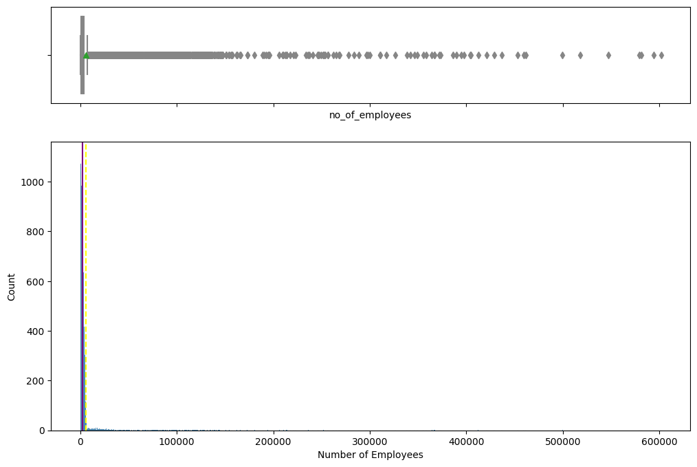

```python
# draw combined histogram and boxplot
histogram_boxplot(data, 'no_of_employees')

# label x axis
plt.xlabel('Number of Employees');
```

#### Observations

- Number of employes has a right-skewed distribution with outliers on one side.

#### Hourly Prevailing Wage

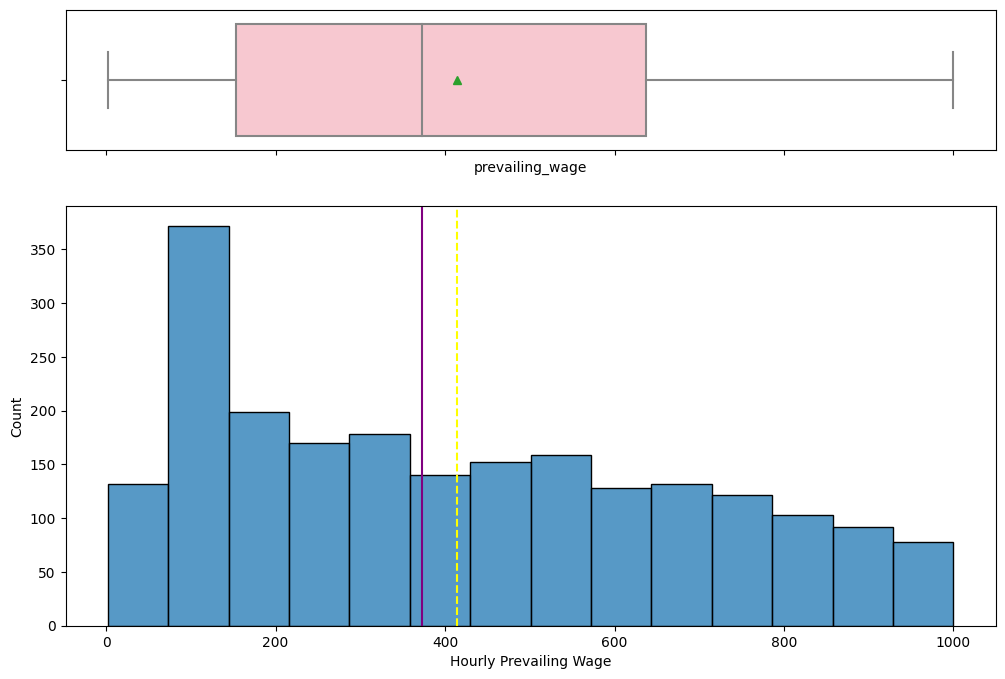

```python
# draw combined histogram and boxplot where unit_of_wage is hourly
histogram_boxplot(data[data['unit_of_wage']=='Hour'], 'prevailing_wage')

# label x axis
plt.xlabel('Hourly Prevailing Wage');
```

#### Observations

- Hourly prevailing wage has a slightly right-skewed distribution with no outliers.
- There is a spike in prevailing wages less than 100.

```python
# check observations with a prevailing wage less than 100
data.loc[data['prevailing_wage'] < 100]
```

|  | continent | education_of_employee | has_job_experience | requires_job_training | no_of_employees | yr_of_estab | region_of_employment | prevailing_wage | unit_of_wage | full_time_position | case_status |
| --- | --- | --- | --- | --- | --- | --- | --- | --- | --- | --- | --- |
| 338 | Asia | Bachelor's | Y | N | 2114 | 2012 | Northeast | 15.7716 | Hour | Y | Certified |
| 634 | Asia | Master's | N | N | 834 | 1977 | Northeast | 3.3188 | Hour | Y | Denied |
| 839 | Asia | High School | Y | N | 4537 | 1999 | West | 61.1329 | Hour | Y | Denied |
| 876 | South America | Bachelor's | Y | N | 731 | 2004 | Northeast | 82.0029 | Hour | Y | Denied |
| 995 | Asia | Master's | N | N | 302 | 2000 | South | 47.4872 | Hour | Y | Certified |
| ... | ... | ... | ... | ... | ... | ... | ... | ... | ... | ... | ... |
| 25023 | Asia | Bachelor's | N | Y | 3200 | 1994 | South | 94.1546 | Hour | Y | Denied |
| 25258 | Asia | Bachelor's | Y | N | 3659 | 1997 | South | 79.1099 | Hour | Y | Denied |
| 25308 | North America | Master's | N | N | 82953 | 1977 | Northeast | 42.7705 | Hour | Y | Denied |
| 25329 | Africa | Bachelor's | N | N | 2172 | 1993 | Northeast | 32.9286 | Hour | Y | Denied |
| 25461 | Asia | Master's | Y | N | 2861 | 2004 | West | 54.9196 | Hour | Y | Denied |

176 rows × 11 columns

```python
# count of entries divided by wage unit type less than 100
data.loc[data['prevailing_wage'] < 100, 'unit_of_wage'].value_counts()
```

```
unit_of_wage
Hour    176
Name: count, dtype: int64
```

#### Observations

- There are 176 hourly values less than 100.

```python
# function to create labeled barplot
def labeled_barplot(data, feature, perc=False, width=None):

    """Create a labeled barplot of a categorical feature.

    Args:
        data (pandas.DataFrame): The input dataset.
        feature (str): The name of the categorical feature to plot.
        perc (bool, optional): Whether to display percentages instead of counts. Defaults to False.
        width (int, optional): The width of the plot. Defaults to None.

    Returns:
        None
    """
    total = len(data[feature])
    count = data[feature].nunique()

    if width is None:
        plt.figure(figsize=(count + 2, 6))
    else:
        plt.figure(figsize=(width + 2, 6))

    plt.xticks(rotation=45, fontsize=15)
    ax = sns.countplot(data=data, x=feature, palette='Paired', order=data[feature].value_counts().index[:width])

    for p in ax.patches:
        label = '{:.1f}%'.format(100 * p.get_height() / total) if perc else p.get_height()

        x, y = p.get_x() + p.get_width() / 2, p.get_height()

        ax.annotate(
            f"{label}",
            (x, y),
            ha='center',
            va='center',
            size=12,
            xytext=(0, 5),
            textcoords='offset points',
        )

    plt.show()
```

#### Continent

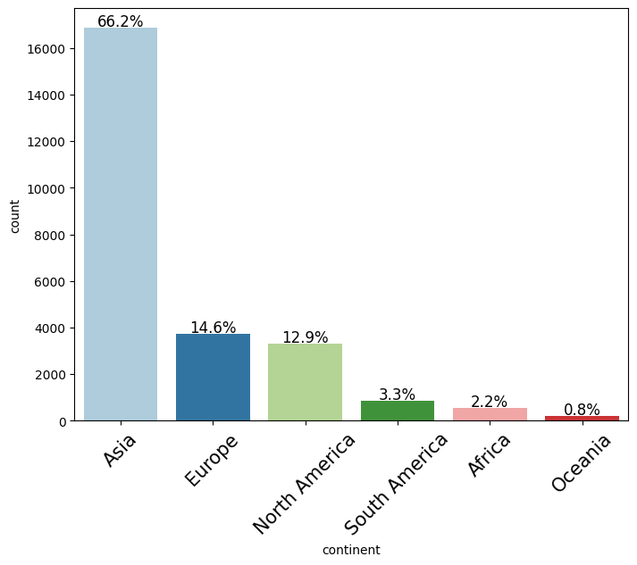

```python
# draw labeled barplot
labeled_barplot(data, 'continent', perc=True)
```

#### Observations

- 66.2% of applicants are from Asia.
- Only 0.8% of applicants are from Oceania.

#### Employee Education

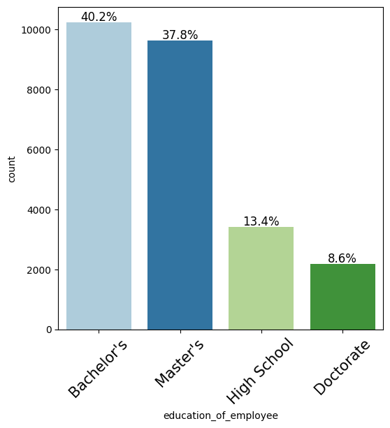

```python
# draw labeled barplot
labeled_barplot(data, 'education_of_employee', perc=True)
```

#### Observations

- The majority of applicants hold a Bachelor's or Master's degree at 40.2% and 37.8% respectively.

#### Job Experience (Y/N)

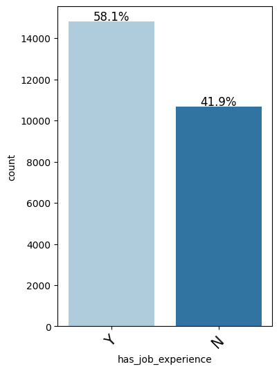

```python
# draw labeled barplot
labeled_barplot(data, 'has_job_experience', perc=True)
```

#### Observations

- 58.1% of applicants have job experience.

#### Job Training (Y/N)

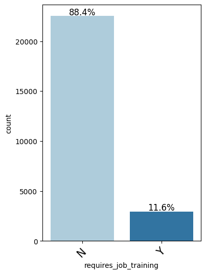

```python
# draw labeled barplot
labeled_barplot(data, 'requires_job_training', perc=True)
```

#### Observations

- 88.4% of applicants do not require job training.

#### Region

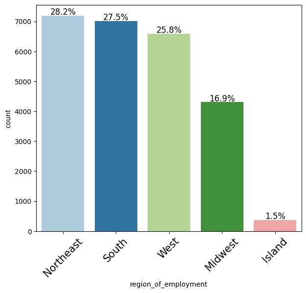

```python
# draw labeled barplot
labeled_barplot(data, 'region_of_employment', perc=True)
```

#### Observations

- The Northeast, South, and West are the most popular destination among immigrants seeking work. They are fairly even at 28.2%, 27.5%, and 25.8% respectively.

#### Unit of Wage

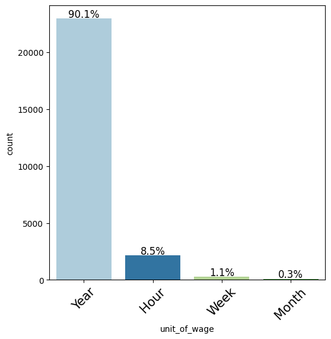

```python
# draw labeled barplot
labeled_barplot(data, 'unit_of_wage', perc=True)
```

#### Observations

- The most popular unit for prevailing wage is yearly salary. This is not surprising as it is an easy unit to measure.

#### Case Status

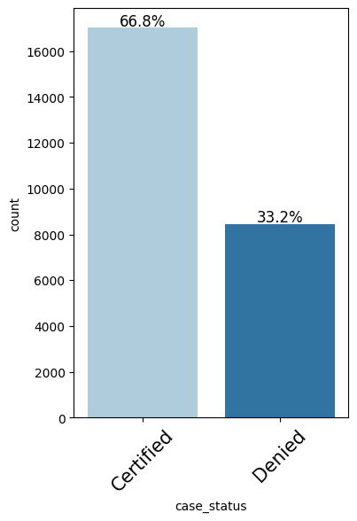

```python
# draw labeled barplot
labeled_barplot(data, 'case_status', perc=True)
```

#### Observations

- 66.8% of visas are approved or certified while 33.2% were denied.

### Bivariate Analysis

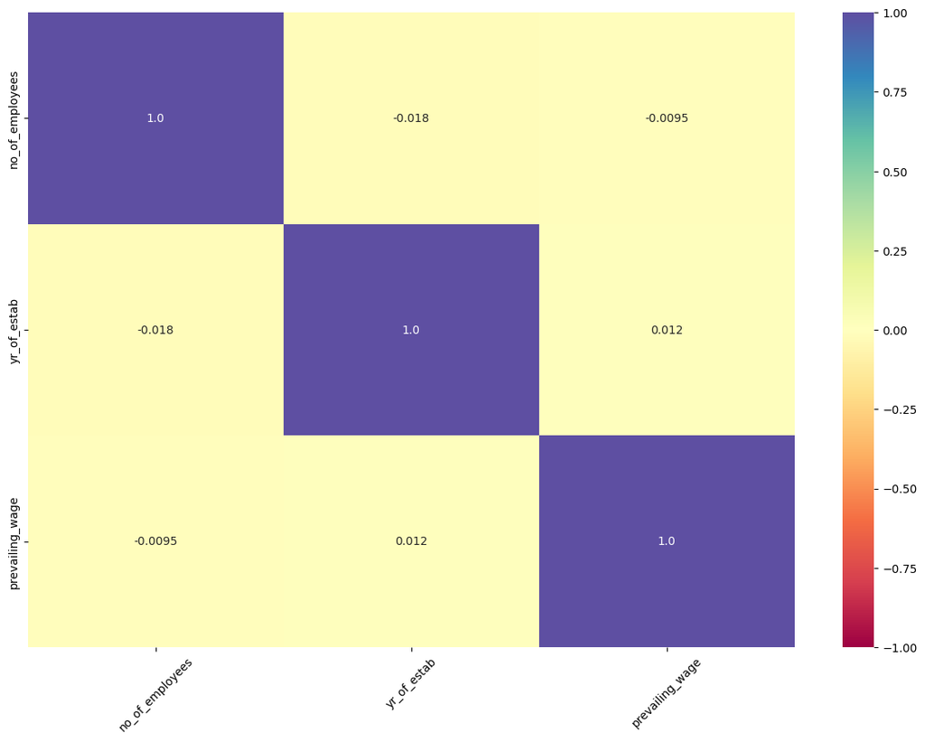

```python
# draw correlation heatmap of numerical columns
cols = data.select_dtypes(include=np.number).columns.tolist()

# set figure size
plt.figure(figsize=(15, 10))

# draw heatmap
sns.heatmap(data[cols].corr(), annot=True, vmin=-1, vmax=1, fmt='.2', cmap='Spectral');

# rotate x labels 45 degrees and set font size to 10
plt.xticks(rotation = 45, fontsize = 10);
```

#### Observations

- There are no strong correlations in the data set.

```python
# create function to plot distributions with respect to target
# used to identify potential patterns and relationships
def wrt_target(data, predictor, target):

    fig, axs = plt.subplots(2, 2, figsize = (12, 10))

    target_uniq = data[target].unique()

    axs[0, 0].set_title('Distribution of Target for Target = ' + str(target_uniq[0]))

    # draw histplot
    sns.histplot(data = data[data[target] == target_uniq[0]],
        x = predictor, kde = True, ax = axs[0, 0], color = 'teal', stat = 'density',)

    axs[0, 1].set_title('Distribution of Target for Target =' + str(target_uniq[1]))

    # draw histplot
    sns.histplot(data = data[data[target] == target_uniq[1]],
        x = predictor, kde = True, ax = axs[0, 1], color = 'orange', stat = 'density',)

    axs[1, 0].set_title('Boxplot W.R.T Target')

    # draw boxplot
    sns.boxplot(data = data, x = target, y = predictor, ax = axs[1, 0], palette = 'gist_rainbow')

    axs[1, 1].set_title('Boxplot (without outliers) W.R.T Target')

   # draw boxplot
    sns.boxplot(data = data, x = target, y = predictor, ax = axs[1, 1], showfliers = False, palette = 'gist_rainbow',)

    plt.tight_layout()
    plt.show()
```

```python
# create function to draw stacked barplots
# good for showing how the composition of a group changes across categories
def stacked_barplot(data, predictor, target):

    count = data[predictor].nunique()
    sorter = data[target].value_counts().index[-1]
    tab1 = pd.crosstab(data[predictor], data[target], margins = True).sort_values(by = sorter, ascending = False)
    print(tab1)
    print('-' * 120)
    tab = pd.crosstab(data[predictor], data[target], normalize = 'index').sort_values(by = sorter, ascending = False)
    tab.plot(kind='bar', stacked=True, figsize=(count + 5, 5))

    # show legend
    plt.legend(loc = 'lower left', frameon = False,)
    plt.legend(loc = 'upper left', bbox_to_anchor = (1, 1))

    plt.show()
```

#### 1. Does education play a role in Visa certification?

```
case_status            Certified  Denied    All
education_of_employee
All                        17018    8462  25480
Bachelor's                  6367    3867  10234
High School                 1164    2256   3420
Master's                    7575    2059   9634
Doctorate                   1912     280   2192
------------------------------------------------------------------------------------------------------------------------
```

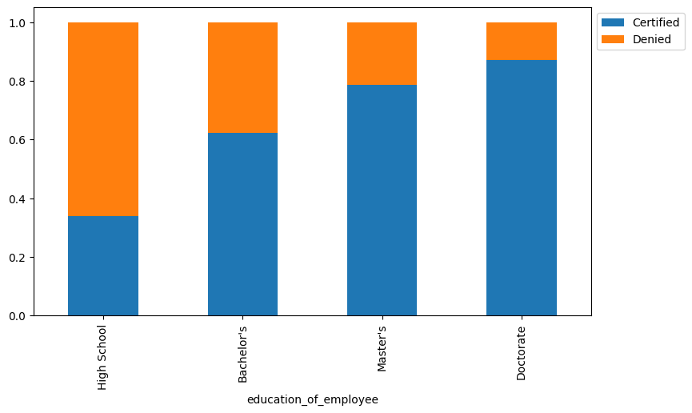

```python
# draw stacked barplot
stacked_barplot(data, 'education_of_employee', 'case_status')
```

```python
# print percentage of denied applications
print(str((8462 / 25480) * 100) + '% of all applications were denied.')
print(str((3867 / 10234) * 100) + "% of all applications where applicants hold a Bachelor's degree were denied.")
print(str((2256 / 3420) * 100) + "% of all applications where applicants hold a High School diploma were denied.")
print(str((2059 / 9634) * 100) + "% of all applications where applicants hold a Master's degree were denied.")
print(str((280 / 2192) * 100) + "% of all applications where applicants hold a Doctorate degree were denied.")
```

```
33.210361067503925% of all applications were denied.
37.785811999218296% of all applications where applicants hold a Bachelor's degree were denied.
65.96491228070175% of all applications where applicants hold a High School diploma were denied.
21.372223375544944% of all applications where applicants hold a Master's degree were denied.
12.773722627737227% of all applications where applicants hold a Doctorate degree were denied.
```

#### Observations

- Overall there are more certified applications than denied applications, with only 33.2% of applications being denied.
- There are less denied applications proportionately among higher education categories: Bachelor's, Master's, and Doctorate.
- There are more denied application among the High School category.
- Approximately 66% of applications where applicants hold a high school diploma are denied.

#### 2. Do different regions have different education requirements?

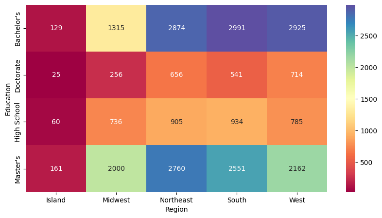

```python
# draw correlation heatmap
plt.figure(figsize=(10, 5))
sns.heatmap(pd.crosstab(data['education_of_employee'], data['region_of_employment']),
    annot=True, fmt='g', cmap='Spectral')

# set labels
plt.ylabel('Education')
plt.xlabel('Region');
```

#### Observations

- There is a strong negative correlation between the Midwest region and Doctorate degrees. There is a slight positive correlation between the Midwest and Master's degrees.
- There is are negative correlations between Island and all degrees. This isn't surprising as only 1.5% of applicants desire this region.
- There are strong positive correlations between both Bachelor's and Master's degrees and the Northeast.
- There are positive correlations between Bachelor's and Master's degrees and the South.
- There are positive correlations between Bachelor's and Master's degrees and the West.

#### 3. Does region affect certification status?

```
case_status           Certified  Denied    All
region_of_employment
All                       17018    8462  25480
Northeast                  4526    2669   7195
West                       4100    2486   6586
South                      4913    2104   7017
Midwest                    3253    1054   4307
Island                      226     149    375
------------------------------------------------------------------------------------------------------------------------
```

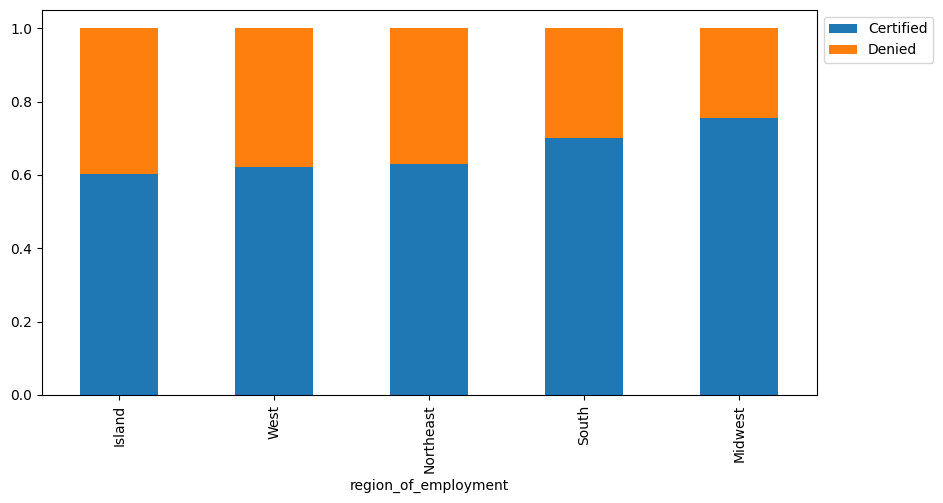

```python
# draw stacked barplot
stacked_barplot(data, 'region_of_employment', 'case_status')
```

```python
# print percentage of certified applications per region
print(str((17018 / 25480) * 100) + '% of all applications certified.')
print(str((4526 / 7195) * 100) + "% of certified applications in the Northeast.")
print(str((4100 / 6586) * 100) + "% of certified applications in the West.")
print(str((4913 / 7017) * 100) + "% of certified applications in the South.")
print(str((3253 / 4307) * 100) + "% of certified applications in the Midwest.")
print(str((226 / 375) * 100) + "% of certified applications in the Island region.")
```

```
66.78963893249608% of all applications certified.
62.90479499652536% of certified applications in the Northeast.
62.25326450045551% of certified applications in the West.
70.01567621490665% of certified applications in the South.
75.52820989087532% of certified applications in the Midwest.
60.266666666666666% of certified applications in the Island region.
```

#### Observations

- 66.8% of all applications are certified.
- This hold true and constant across the majority of regions with percentages ranging from approximately 62% to 75% certified.
- Region is unlikely to affect the chance of application certification.

#### 4. How does the visa status vary across different continents?

```
case_status    Certified  Denied    All
continent
All                17018    8462  25480
Asia               11012    5849  16861
North America       2037    1255   3292
Europe              2957     775   3732
South America        493     359    852
Africa               397     154    551
Oceania              122      70    192
------------------------------------------------------------------------------------------------------------------------
```

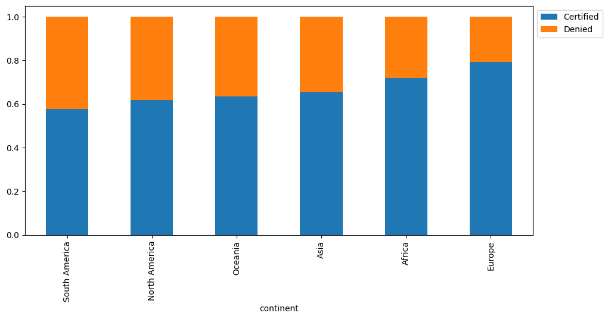

```python
# draw stacked barplot
stacked_barplot(data, 'continent', 'case_status')
```

```python
# print percentage of certfied applications per continent
print(str((17018 / 25480) * 100) + '% of all applications certified.')
print(str((11012 / 16861) * 100) + "% of certified applications in Asia.")
print(str((2037 / 3292) * 100) + "% of certified applications in North America.")
print(str((2957 / 3732) * 100) + "% of certified applications in Europe.")
print(str((493 / 852) * 100) + "% of certified applications in South America.")
print(str((397 / 551) * 100) + "% of certified applications in Africa.")
print(str((122 / 192) * 100) + "% of certified applications in Oceania.")
```

```
66.78963893249608% of all applications certified.
65.31047980546823% of certified applications in Asia.
61.87727825030377% of certified applications in North America.
79.23365487674168% of certified applications in Europe.
57.863849765258216% of certified applications in South America.
72.0508166969147% of certified applications in Africa.
63.541666666666664% of certified applications in Oceania.
```

#### Observations

- Percentages of certified applications range between 58% to 79%, showing a slight variable difference depending on continent.
- Continent is unlikely to affect certification status in a meaningful way.

#### 5. Does work experience impact certification status?

```
case_status         Certified  Denied    All
has_job_experience
All                     17018    8462  25480
N                        5994    4684  10678
Y                       11024    3778  14802
------------------------------------------------------------------------------------------------------------------------
```

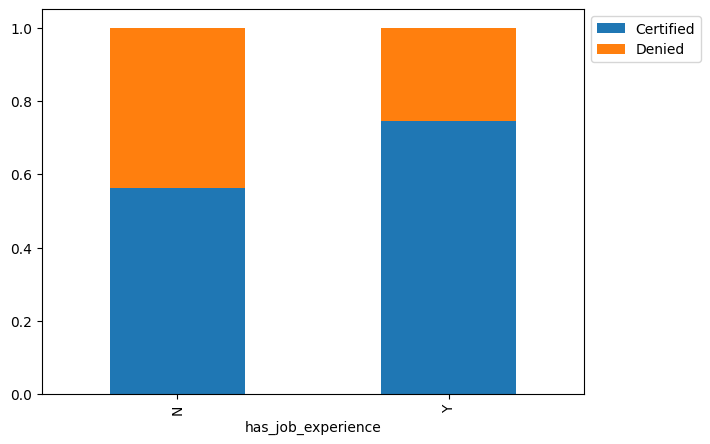

```python
# draw stacked barplot
stacked_barplot(data, 'has_job_experience', 'case_status')
```

```python
# print percentage of certfied applications per experience Y/N
print(str((5994 / 10678) * 100) + '% of certified applications where applicant does not have previous job experience.')
print(str((11024 / 14802) * 100) + "% of certified applications where applicant has previous job experience.")
```

```
56.1341075107698% of certified applications where applicant does not have previous job experience.
74.47642210512093% of certified applications where applicant has previous job experience.
```

#### Observations

- 56% of applicants with no prior job experiences recieve certification.
- 74.5% of applicants with preveious job experience recieve certification.
- There is a slight preference towards job experience and positive certification status.

#### 6. Do employees with work experience require job training?

```
requires_job_training      N     Y    All
has_job_experience
All                    22525  2955  25480
N                       8988  1690  10678
Y                      13537  1265  14802
------------------------------------------------------------------------------------------------------------------------
```

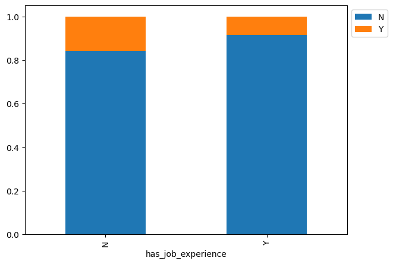

```python
# draw stacked barplot
stacked_barplot(data, 'has_job_experience', 'requires_job_training')
```

#### Observations

- Employees with and without prior job experience largely do not require job training. This could be self-reported sample bias to appear more employable.

#### 7. How does the visa status change with the prevailing wage?

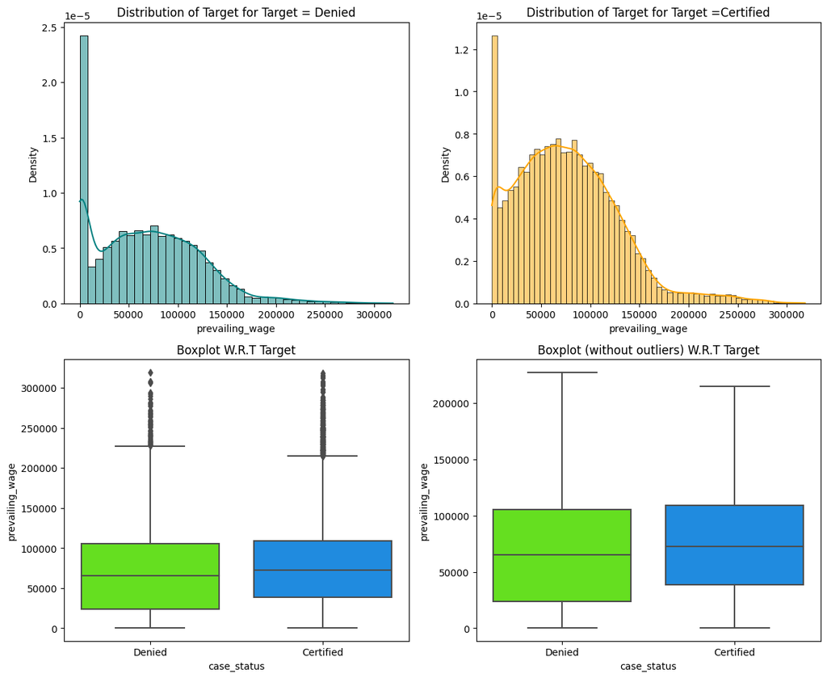

```python
# draw with repsect to target plots
wrt_target(data, 'prevailing_wage', 'case_status')
```

#### Observations

- There are outliers in both distributions.
- The median prevailing wage is slightly higher for certified applications. However, the distributions between denied and certified applications against prevailing wage are similar.

#### 8. How does prevailing wage vary across regions?

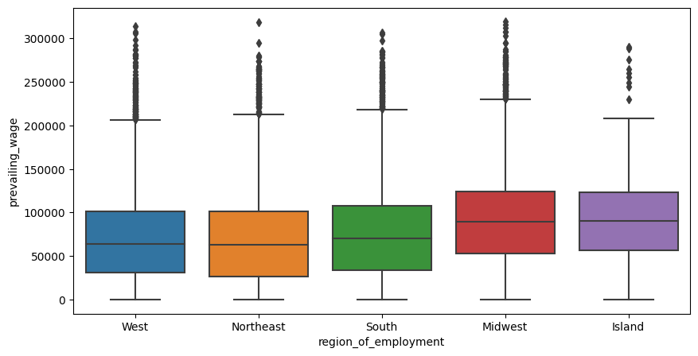

```python
# draw boxpots of prevailing wage and region
plt.figure(figsize=(10, 5))
sns.boxplot(x='region_of_employment', y='prevailing_wage', data=data);
```

#### Observations

- Prevailing wage is predominantly similar across regions. It is slightly higher for the Midwest and Island regions.

#### 9. Do wage units impact certification status?

```
case_status   Certified  Denied    All
unit_of_wage
All               17018    8462  25480
Year              16047    6915  22962
Hour                747    1410   2157
Week                169     103    272
Month                55      34     89
------------------------------------------------------------------------------------------------------------------------
```

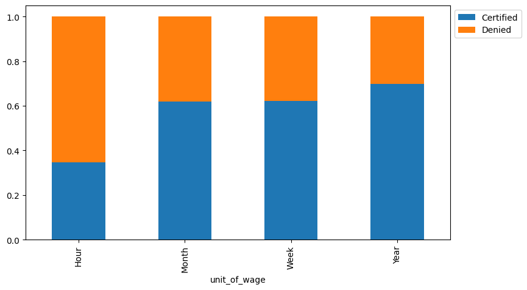

```python
# draw stacked barplot
stacked_barplot(data, 'unit_of_wage', 'case_status')
```

```python
# print percentage of denied applications with hourly wage units
print(str((1410 / 2157) * 100) + '% of denied applications where prevailing wage used hourly units.')
```

```
65.36856745479834% of denied applications where prevailing wage used hourly units.
```

#### Observations

- Hourly wage units have a higher denial chance than other units at 65%.

## Data Preprocessing

- Missing value treatment (if needed)
- Feature engineering
- Outlier detection and treatment (if needed)
- Preparing data for modeling
- Any other preprocessing steps (if needed)

#### Outlier Detection

- There were no missing values to treat.

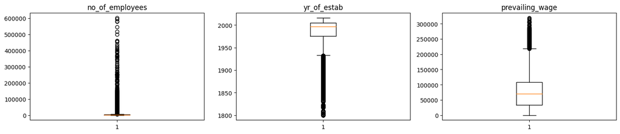

```python
# outlier detection using boxplot
numeric_columns = data.select_dtypes(include=np.number).columns.tolist()

# set figure size
plt.figure(figsize=(15, 12))

for i, variable in enumerate(numeric_columns):
    plt.subplot(4, 3, i+1)
    plt.boxplot(data[variable], whis=1.5)
    plt.title(variable)

plt.tight_layout()
plt.show()
```

#### Observations

- There are outliers in the data set.
- The outliers do not need treated, because they are proper values.

### Data Preparation

- The goal is to predict visa certification.

```python
# convert case_status to binary, 1 = Certified and 0 = Denied
data['case_status'] = data['case_status'].apply(lambda x: 1 if x == 'Certified' else 0)

# drop case_status column to create feature matrix X
X = data.drop('case_status', axis=1)

# create dummy variables for all categorical variables in X
X = pd.get_dummies(X)

# create target variable Y
Y = data['case_status']

# split data into training and testing with 70:30 ratio, stratification based on case_status
X_train, X_test, y_train, y_test = train_test_split(X, Y, test_size=0.3, random_state=1, stratify=Y)
```

```python
# 1 = Certified and 0 = Denied
print('The shape of training set : ', X_train.shape)
print('The shape of test set : ', X_test.shape)
print('Percentage of classes in training set:')
print(y_train.value_counts(normalize=True))
print('Percentage of classes in test set:')
print(y_test.value_counts(normalize=True))
```

```
The shape of training set :  (17836, 28)
The shape of test set :  (7644, 28)
Percentage of classes in training set:
case_status
1    0.667919
0    0.332081
Name: proportion, dtype: float64
Percentage of classes in test set:
case_status
1    0.667844
0    0.332156
Name: proportion, dtype: float64
```

#### Observations

- Around 67% of applications are certified in the training set.
- This is preserved in the testing set where we see approximately 67% of applications are certified.
- The model's accuracy can be improved from 67%.

## EDA

- It is a good idea to explore the data once again after manipulating it.

### Number of Employees

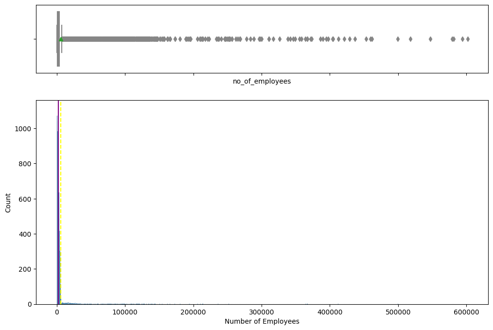

```python
# draw combined histogram and boxplot
histogram_boxplot(data, 'no_of_employees')

# label x axis
plt.xlabel('Number of Employees');
```

#### Observations

### Prevailing Wage

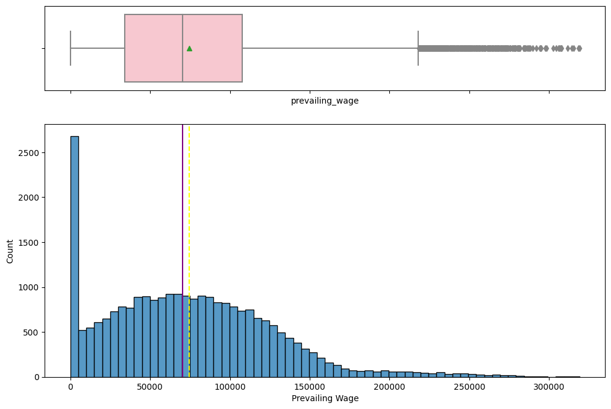

```python
# draw combined histogram and boxplot where unit_of_wage is hourly
histogram_boxplot(data, 'prevailing_wage')

# label x axis
plt.xlabel('Prevailing Wage');
```

#### Observations

### Correlation Heatmap

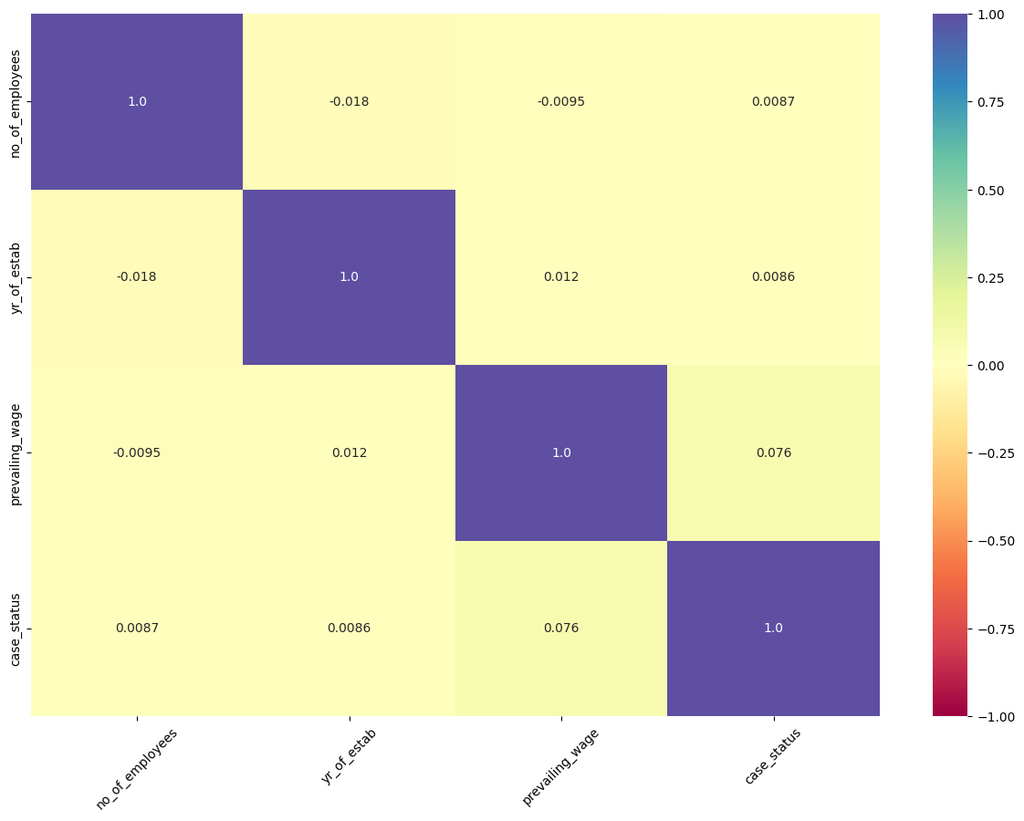

```python
# draw correlation heatmap of numerical columns
cols = data.select_dtypes(include=np.number).columns.tolist()

# set figure size
plt.figure(figsize=(15, 10))

# draw heatmap
sns.heatmap(data[cols].corr(), annot=True, vmin=-1, vmax=1, fmt='.2', cmap='Spectral');

# rotate x labels 45 degrees and set font size to 10
plt.xticks(rotation = 45, fontsize = 10);
```

#### Observations

## Building bagging and boosting models

#### Model evaluation criterion

Wrong Predictions:

1. Model predicts visa application will get certified, but the visa application should get denied.
2. Model predicts visa application will not get certified, but the visa application should get certified.

We will evaluate models using F1-score. Higher F1-score values minimize false negatives and false positives.

```python
# define a function to compute classification performance metrics
def model_performance_classification_sklearn(model, predictors, target):

    # generate predictions using the model
    pred = model.predict(predictors)

    # calculate the classification metrics
    acc = accuracy_score(target, pred)
    recall = recall_score(target, pred)
    precision = precision_score(target, pred)
    f1 = f1_score(target, pred)

    # create a dataframe to store the performance metrics
    df_perf = pd.DataFrame(
        {'Accuracy': acc, 'Recall': recall, 'Precision': precision, 'F1': f1,},
        index=[0],)

    return df_perf
```

```python
# define a function to create a confusion matrix using sklearn and seaborn
def confusion_matrix_sklearn(model, predictors, target):

    # generate predictions using the model
    y_pred = model.predict(predictors)

    # calculate the confusion matrix
    cm = confusion_matrix(target, y_pred)

    # format the labels for the heatmap annotations
    labels = np.asarray(
        [
            ['{0:0.0f}'.format(item) + '\n{0:.2%}'.format(item / cm.flatten().sum())]
            for item in cm.flatten()
        ]
    ).reshape(2, 2)

    # create a heatmap using seaborn to visualize the confusion matrix
    plt.figure(figsize=(6, 4))
    sns.heatmap(cm, annot=labels, fmt="")
    plt.ylabel('True label')
    plt.xlabel('Predicted label')
```

### Decision Tree

```python
# create decision tree classifier
model = DecisionTreeClassifier(random_state=1)

# fit classifier to training data
model.fit(X_train, y_train)
```

```
DecisionTreeClassifier(random_state=1)
```

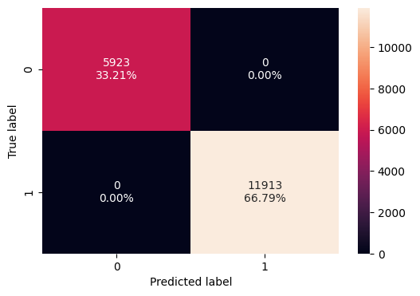

```python
# draw confusion matrix of train set
confusion_matrix_sklearn(model, X_train, y_train)
```

```python
# check performance of train set
decision_tree_perf_train = model_performance_classification_sklearn(model, X_train, y_train)
decision_tree_perf_train
```

|  | Accuracy | Recall | Precision | F1 |
| --- | --- | --- | --- | --- |
| 0 | 1.0 | 1.0 | 1.0 | 1.0 |

#### Observations

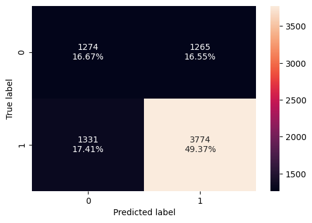

```python
# draw confusion matrix of test set
confusion_matrix_sklearn(model, X_test, y_test)
```

#### Observations

```python
# check performance of test set
decision_tree_perf_test = model_performance_classification_sklearn(model, X_test, y_test)
decision_tree_perf_test
```

|  | Accuracy | Recall | Precision | F1 |
| --- | --- | --- | --- | --- |
| 0 | 0.660387 | 0.739275 | 0.748958 | 0.744085 |

#### Will tuning the hyperparameters improve the model performance?

```python
# tuned decision tree classifier
dtree_estimator = DecisionTreeClassifier(class_weight='balanced', random_state=1)

# grid of parameters to choose from
parameters = {
    'max_depth': np.arange(5, 16, 5),
    'min_samples_leaf': [3, 5, 7],
    'max_leaf_nodes': [2, 5],
    'min_impurity_decrease': [0.0001, 0.001],
}

# set score to f1_score
acc_scorer = metrics.make_scorer(metrics.f1_score)

# run grid search
grid_obj = GridSearchCV(dtree_estimator, parameters, scoring=acc_scorer, n_jobs=-1)

# fit model on train set
grid_obj = grid_obj.fit(X_train, y_train)

# set clf to best combination of parameters
dtree_estimator = grid_obj.best_estimator_

# fit the best algorithm
dtree_estimator.fit(X_train, y_train)
```

```
DecisionTreeClassifier(class_weight='balanced', max_depth=5, max_leaf_nodes=2,
                       min_impurity_decrease=0.0001, min_samples_leaf=3,
                       random_state=1)
```

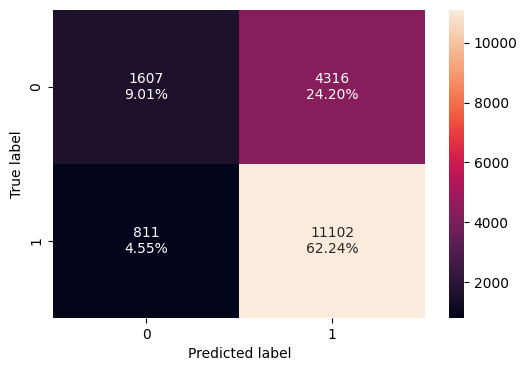

```python
# draw confusion matrix of train set on tuned estimator
confusion_matrix_sklearn(dtree_estimator, X_train, y_train)
```

#### Observations

```python
# check performance of train data on tuned estimator
dtree_estimator_model_train_perf = model_performance_classification_sklearn(dtree_estimator, X_train, y_train)
dtree_estimator_model_train_perf
```

|  | Accuracy | Recall | Precision | F1 |
| --- | --- | --- | --- | --- |
| 0 | 0.712548 | 0.931923 | 0.720067 | 0.812411 |

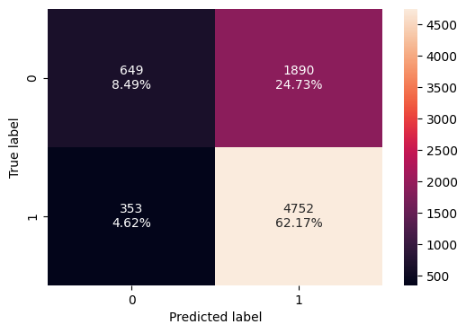

```python
# draw confusion matrix of test data on tuned estimator
confusion_matrix_sklearn(dtree_estimator, X_test, y_test)
```

#### Observations

```python
# check performance of test data on tuned estimator
dtree_estimator_model_test_perf = model_performance_classification_sklearn(dtree_estimator, X_test, y_test)
dtree_estimator_model_test_perf
```

|  | Accuracy | Recall | Precision | F1 |
| --- | --- | --- | --- | --- |
| 0 | 0.706567 | 0.930852 | 0.715447 | 0.809058 |

#### Observations

- The results for the train and test sets are similar indicating the model is likely not overfitting.
- The accuracy of both sets is around 71%, indicating the model correctly classified aproximately 71% of observations in both sets.
- The recall for both sets is high around 93%, indicating the model correctly identified a high proportion of positive cases for both sets.
- The precision is similar at 72% for both sets, indicating indicating that the model is correctly predicting positive cases in both sets.
- The F1-score is similar on both sets at 81%.
- Overall, the performance metrics for both sets are similar indicating that the model is generalizing well to new data.

#### Bagging Classifier

```python
# create bagging classifier
bagging_classifier = BaggingClassifier(random_state=1)

# fit on train set
bagging_classifier.fit(X_train,y_train)
```

```
BaggingClassifier(random_state=1)
```

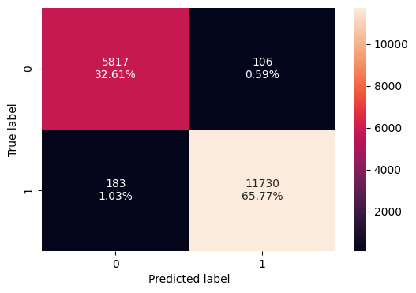

```python
# draw confusion matrix of train data on bagging classifier
confusion_matrix_sklearn(bagging_classifier,X_train,y_train)
```

#### Observations

```python
# check performance of train data on bagging classifier
bagging_classifier_model_train_perf = model_performance_classification_sklearn(bagging_classifier,X_train,y_train)
bagging_classifier_model_train_perf
```

|  | Accuracy | Recall | Precision | F1 |
| --- | --- | --- | --- | --- |
| 0 | 0.983797 | 0.984639 | 0.991044 | 0.987831 |

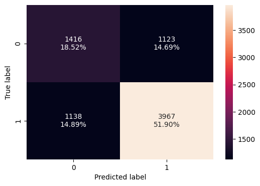

```python
# draw confusion matrix of test data on bagging classifier
confusion_matrix_sklearn(bagging_classifier,X_test,y_test)
```

#### Observations

```python
# check performance of test data on bagging classifier
bagging_classifier_model_test_perf = model_performance_classification_sklearn(bagging_classifier,X_test,y_test)
bagging_classifier_model_test_perf
```

|  | Accuracy | Recall | Precision | F1 |
| --- | --- | --- | --- | --- |
| 0 | 0.704212 | 0.777081 | 0.779371 | 0.778225 |

#### Will tuning the hyperparameters improve the model performance?

```python
# tuned bagging classifier
bagging_estimator_tuned = BaggingClassifier(random_state=1)

# grid of parameters to choose from
parameters = {
    'max_samples': [0.7, 0.9],
    'max_features': [0.7, 0.9],
    'n_estimators': np.arange(90, 111, 10),
}

# set scorer to f1_score
acc_scorer = metrics.make_scorer(metrics.f1_score)

# run grid search
grid_obj = GridSearchCV(bagging_estimator_tuned, parameters, scoring=acc_scorer, cv=5)

# fit tuned bagging classifier on train set
grid_obj = grid_obj.fit(X_train, y_train)

# set clf to best combination of parameters
bagging_estimator_tuned = grid_obj.best_estimator_

# fit best algorithm
bagging_estimator_tuned.fit(X_train, y_train)
```

```
BaggingClassifier(max_features=0.7, max_samples=0.7, n_estimators=100,
                  random_state=1)
```

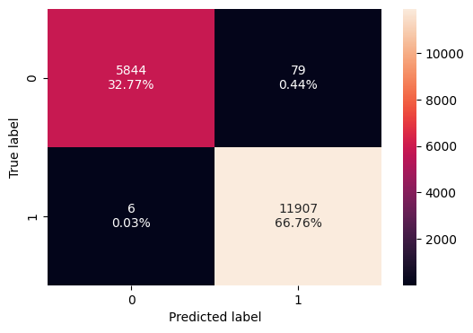

```python
# draw confusion matrix of train data on tuned bagging estimator
confusion_matrix_sklearn(bagging_estimator_tuned,X_train,y_train)
```

#### Observations

```python
# check performance of train data on tuned bagging estimator
bagging_classifier_model_tuned_train_perf = model_performance_classification_sklearn(bagging_estimator_tuned,X_train,y_train)
bagging_classifier_model_tuned_train_perf
```

|  | Accuracy | Recall | Precision | F1 |
| --- | --- | --- | --- | --- |
| 0 | 0.995234 | 0.999496 | 0.993409 | 0.996443 |

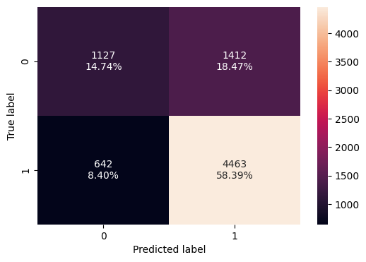

```python
# draw confusion matrix of test data on tuned bagging estimator
confusion_matrix_sklearn(bagging_estimator_tuned,X_test,y_test)
```